# Sales Forecast with ARIMA

Iryna G Duda

- The purpose of the analysis is to explore and find best ARIMA model used for forecasting future sales.

### 1.Preparing Data

```r
dataset <- read.csv("Data_072020.csv")
headTail(dataset, 3)
```

|  | Yr | Mo_No | Date | AvgSold | AvgShipTo | AvgWeekly_Inv | TotalUniqSoldTos | TotalUniqShipTos | TotalInv |
| --- | --- | --- | --- | --- | --- | --- | --- | --- | --- |
| 1 | 2020 | 7 | 7/1/2020 | 187 | 278 | 177403.28 | 4864 | 7233 | 4612485.23 |
| 2 | 2020 | 6 | 6/1/2020 | 206 | 298 | 154289.38 | 5153 | 7457 | 3857234.51 |
| 3 | 2020 | 5 | 5/1/2020 | 173 | 236 | 130550.71 | 3821 | 5206 | 2872115.58 |
| ... | ... | ... | NA | ... | ... | ... | ... | ... | ... |
| 52 | 2016 | 4 | 4/1/2016 | 203 | 245 | 114009.71 | 4473 | 5403 | 2508213.51 |
| 53 | 2016 | 3 | 3/1/2016 | 219 | 265 | 121933.76 | 5264 | 6362 | 2926410.14 |
| 54 | 2016 | 2 | 2/1/2016 | 227 | 273 | 130722.16 | 4775 | 5753 | 2745165.31 |
| 55 | 2016 | 1 | 1/1/2016 | 192 | 232 | 111036.55 | 4241 | 5112 | 2442804.13 |

```r
dataset <- data.frame(dataset)
attach(dataset)
dataset$Yr <- as.factor(Yr)
dataset$Mo_No <- as.factor(Mo_No)
dataset$Date <- as.Date(dataset$Date, format = "%m/%d/%Y")  #format='%B %d %Y'
head(dataset, 3)
```

|  | Yr | Mo_No | Date | AvgSold | AvgShipTo | AvgWeekly_Inv | TotalUniqSoldTos | TotalUniqShipTos | TotalInv |
| --- | --- | --- | --- | --- | --- | --- | --- | --- | --- |
| 1 | 2020 | 7 | 2020-07-01 | 187 | 278 | 177403.3 | 4864 | 7233 | 4612485 |
| 2 | 2020 | 6 | 2020-06-01 | 206 | 298 | 154289.4 | 5153 | 7457 | 3857235 |
| 3 | 2020 | 5 | 2020-05-01 | 173 | 236 | 130550.7 | 3821 | 5206 | 2872116 |

```r
dataset$AvgWeekly_Inv <- as.numeric(AvgWeekly_Inv)
dataset$TotalInv <- as.numeric(TotalInv)
dataset <- dataset[order(dataset$Date, dataset$Mo_No), ]
attach(dataset)
des(dataset)
```

```
##
##  No. of observations =  55
##   Variable         Class           Description
## 1 Yr               factor
## 2 Mo_No            factor
## 3 Date             Date
## 4 AvgSold          integer
## 5 AvgShipTo        integer
## 6 AvgWeekly_Inv    numeric
## 7 TotalUniqSoldTos integer
## 8 TotalUniqShipTos integer
## 9 TotalInv         numeric
```

```r
head(dataset, 3)
```

|  | Yr | Mo_No | Date | AvgSold | AvgShipTo | AvgWeekly_Inv | TotalUniqSoldTos | TotalUniqShipTos | TotalInv |
| --- | --- | --- | --- | --- | --- | --- | --- | --- | --- |
| 55 | 2016 | 1 | 2016-01-01 | 192 | 232 | 111036.6 | 4241 | 5112 | 2442804 |
| 54 | 2016 | 2 | 2016-02-01 | 227 | 273 | 130722.2 | 4775 | 5753 | 2745165 |
| 53 | 2016 | 3 | 2016-03-01 | 219 | 265 | 121933.8 | 5264 | 6362 | 2926410 |

### 2. Exploring Data

Current dataset consist of 4+ years of data, including outliers like sales during pandemic. For forecasting purpose only range of 13 to 50 will be used in the predictive analysis.

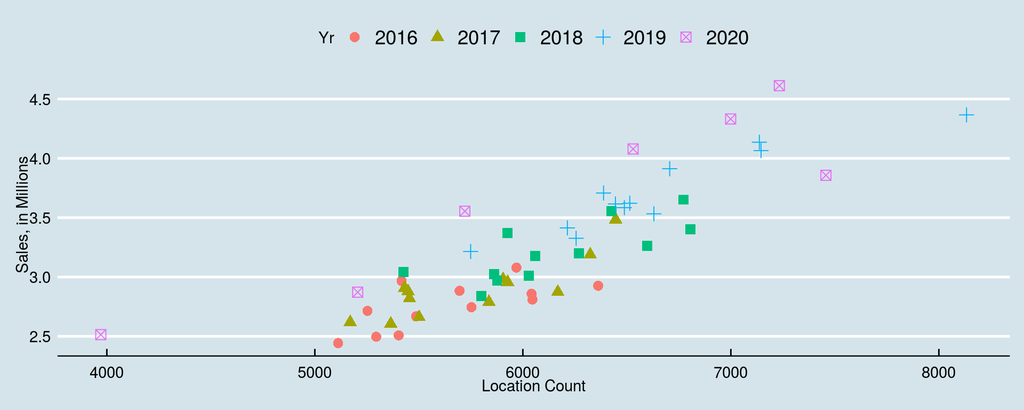

```r
library(ggthemes)
(p1 <- ggplot(dataset, aes(x = TotalUniqShipTos, y = TotalInv/1e+06,
    col = Yr, shape = Yr)) + geom_point(size = 3) + theme_economist() +
    xlab("Location Count") + ylab("Sales, in Millions"))
```

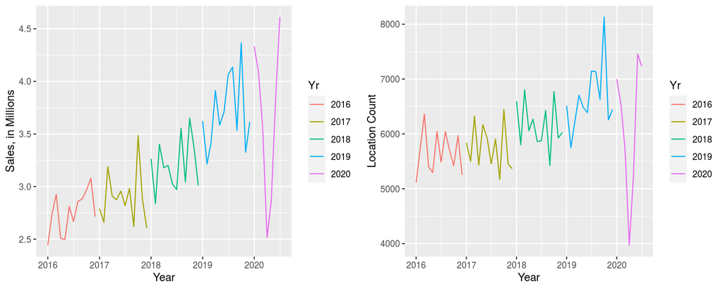

```r
p2 <- ggplot(dataset, aes(x = Date, y = TotalInv/1e+06, col = Yr,
    shape = Yr)) + geom_line(size = 0.5) + xlab("Year") + ylab("Sales, in Millions")
p3 <- ggplot(dataset, aes(x = Date, y = TotalUniqShipTos, col = Yr,
    shape = Yr, show.legend = FALSE)) + geom_line(size = 0.5) +
    xlab("Year") + ylab("Location Count")
grid.arrange(p2, p3, ncol = 2)
```

### 3. Evaluating ACF and PACF plots

ACF plot shows the significant correlation between current time series and previous lags. Typically, such assumption is appropriate when time series, represented by vertical lines, cross the level of significance (blue dashed line) just as it dispalys. Also, observation suggests presence of correlation between the last 3 terms, which makes the lag possibly equal to 3. Since time series drop gradually, there is an assumption of non-stationary data behavior. Versus, if there was a sudden drop it would point on the stationary data and zero correlation between lags.  
PACF also suggests lag equal to 3, because of the first three vertical lines, that are above the 95% of significance level.  
To verify above assumptions, adf.test() is performed. Null hypothesis is that data is non-stationary. Since p-value is 0.144 which is more then excepted 0.05, we fail to reject null hypothesis and have enough evidence to assume that the data is non-stationary. Adf.test() also recommends lag of 3, which confirms findings from the plots.

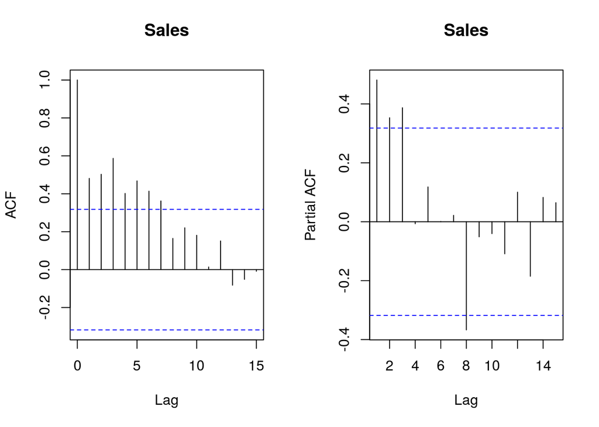

```r
par(mfrow = c(1, 2))
# Modeling time series against Invoice Values per plots ACF
# and PACF
acf(as.ts(dataset[13:50, ]$TotalInv), main = "Sales")  #excluded years 2020 [52:54,] and 2016
pacf(as.ts(dataset[13:50, ]$TotalInv), main = "Sales")
```

```r
par(mfrow = c(1, 1))

tseries::adf.test(TotalInv[13:50], alternative = "stationary")
```

```
##
##  Augmented Dickey-Fuller Test
##
## data:  TotalInv[13:50]
## Dickey-Fuller = -3.0986, Lag order = 3, p-value =
## 0.144
## alternative hypothesis: stationary
```

### 4. Fitting AUTO.ARIMA(0,1,1)(0,1,0)[12]

```r
ts <- ts(dataset$TotalInv[13:50], frequency = 12)
ts1 <- window(ts)
(arima1 <- auto.arima(ts1, D = 1))  # suggested order of (0,1,1)(0,1,0)[12]  AIC=700.67
```

```
## Series: ts1
## ARIMA(0,1,1)(0,1,0)[12]
##
## Coefficients:
##           ma1
##       -0.7929
## s.e.   0.1185
##
## sigma^2 estimated as 7.42e+10:  log likelihood=-348.33
## AIC=700.67   AICc=701.21   BIC=703.11
```

### 5. Forecasting 4 months ahead using AUTO.ARIMA(0,1,1)(0,1,0)[12] and comparing to the fitted values

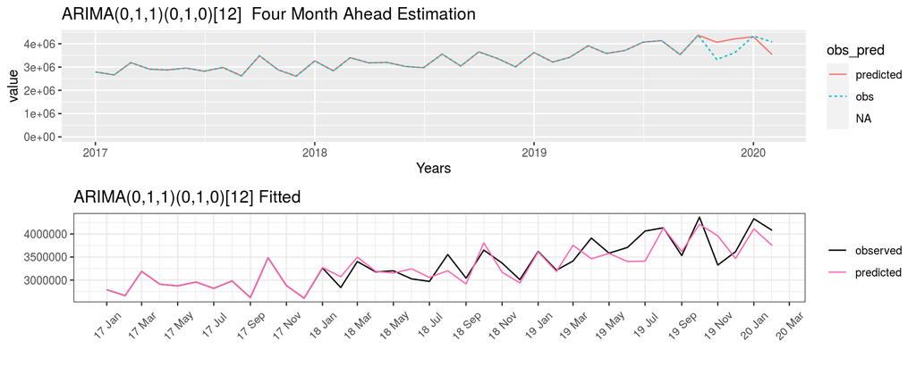

```r
train_index <- 46
n_total <- nrow(dataset[13:50, ])
dataset_train1 <- (dataset[13:(train_index), ])  # training 1-46
dataset_test <- dataset[(train_index + 1):50, ]  # testing 47-50
predicted <- numeric((n_total + 12 - train_index))  #50-46=4
for (i in 1:(n_total - train_index + 12)) {
    dataset_train <- dataset[13:(train_index - 1 + i), ]
    arima.model <- auto.arima(ts(dataset_train$TotalInv))
    pred <- forecast(arima.model, 1)
    predicted[i] <- pred$mean
}
# Four Month Ahead Estimated Observed vs Predicted
df_1_1mo <- tibble(obs = c(dataset_train1$TotalInv, dataset_test$TotalInv),
    predicted = c(dataset_train1$TotalInv, predicted), time = dataset[13:50,
        ]$Date) %>% mutate(abs_error = abs(obs - predicted)/obs)


# Plot Four Month Ahead Estimation
A_1mo <- ggplot(gather(df_1_1mo, obs_pred, value, -time) %>%
    mutate(obs_pred = factor(obs_pred, levels = c("predicted",
        "obs"))), aes(x = time, y = value, col = obs_pred, linetype = obs_pred)) +
    geom_line() + xlab("Years") + ggtitle("ARIMA(0,1,1)(0,1,0)[12]  Four Month Ahead Estimation")

# Fitted Observed vs Predicted
df_fitted1 <- tibble(observed = dataset$TotalInv[13:50], predicted = as.numeric(arima1$fitted),
    time = dataset$Date[13:50]) %>% mutate(abs_error = abs(observed -
    predicted)/observed)



fitted1 <- ggplot(gather(df_fitted1 %>% dplyr::select(-abs_error),
    obs_pred, TotalInv, -time), aes(x = time, y = TotalInv, col = obs_pred)) +
    geom_line() + xlab("") + ylab("") + ggtitle("ARIMA(0,1,1)(0,1,0)[12] Fitted") +
    scale_color_manual(values = c("black", "hotpink")) + scale_x_date(date_labels = "%y %b",
    date_breaks = "2 month") + theme_bw() + theme(legend.title = element_blank(),
    axis.text.x = element_text(angle = 45, vjust = 0.5))

# Two Plots and Tibble Together
grid.arrange(A_1mo, fitted1, nrow = 2)
```

```r
tail(df_1_1mo)
```

| obs | predicted | time | abs_error |
| --- | --- | --- | --- |
| 3532631 | 3532631 | 2019-09-01 | 0.000000000 |
| 4366414 | 4366414 | 2019-10-01 | 0.000000000 |
| 3326330 | 4063612 | 2019-11-01 | 0.221650311 |
| 3615882 | 4210084 | 2019-12-01 | 0.164331065 |
| 4331877 | 4299140 | 2020-01-01 | 0.007557123 |
| 4079161 | 3535931 | 2020-02-01 | 0.133171969 |

```r
tail(df_fitted1)
```

| observed | predicted | time | abs_error |
| --- | --- | --- | --- |
| 3532631 | 3619130 | 2019-09-01 | 0.02448596 |
| 4366414 | 4211472 | 2019-10-01 | 0.03548489 |
| 3326330 | 3960337 | 2019-11-01 | 0.19060260 |
| 3615882 | 3469628 | 2019-12-01 | 0.04044776 |
| 4331877 | 4112492 | 2020-01-01 | 0.05064429 |
| 4079161 | 3750957 | 2020-02-01 | 0.08045874 |

### 6. Adding Number of Locations as a Regressor to the ARIMA model(1,0,0)(0,1,0)[12]

AIC suggests that previous model is more quality fitted compare to the current one. However, AIC difference is not big.  
AIC of model(1,0,0)(0,1,0)[12] is 713.09 while AIC of model(0,1,1)(0,1,0)[12] is 700.67.

```r
# Adding XREG=ShipTo in arima model
(arima2 <- auto.arima(ts1, D = 1, xreg = cbind(as.numeric(dataset$TotalUniqShipTos[13:50]))))  #AIC=713.09
```

```
## Series: ts1
## Regression with ARIMA(1,0,0)(0,1,0)[12] errors
##
## Coefficients:
##          ar1      drift      xreg
##       0.3603  17728.739  484.8645
## s.e.  0.1964   6036.185   97.7323
##
## sigma^2 estimated as 3.945e+10:  log likelihood=-352.55
## AIC=713.09   AICc=715   BIC=718.13
```

```r
# AIC ARIMA comparison
summary(arima1)  #AIC=700.67
```

```
## Series: ts1
## ARIMA(0,1,1)(0,1,0)[12]
##
## Coefficients:
##           ma1
##       -0.7929
## s.e.   0.1185
##
## sigma^2 estimated as 7.42e+10:  log likelihood=-348.33
## AIC=700.67   AICc=701.21   BIC=703.11
##
## Training set error measures:
##                   ME     RMSE      MAE       MPE     MAPE
## Training set 32360.1 216482.9 131083.7 0.6361222 3.672985
##                   MASE        ACF1
## Training set 0.2993226 -0.04389065
```

### 7. Forecasting 4 months ahead using AUTO.ARIMA(1,0,0)(0,1,0)[12]] and comparing to the fitted values

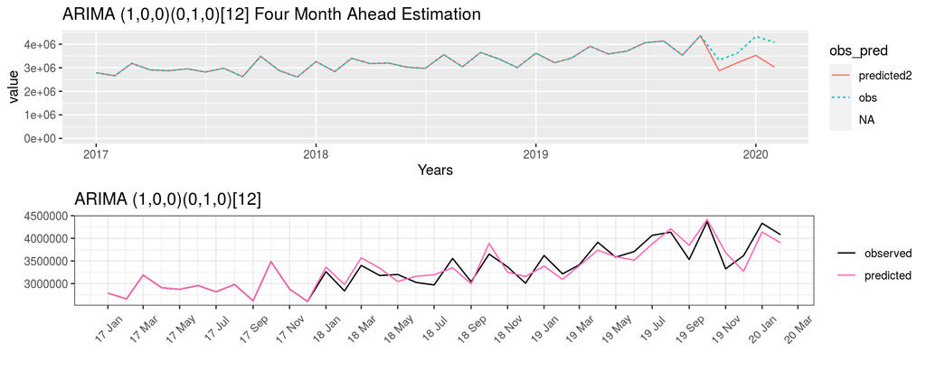

```r
# Forecasting of 4 mo ahead arima1 Training and testing of
# arima1 model
train_index2 <- 46
n_total2 <- nrow(dataset[13:50, ])  #38
dataset_train2 <- (dataset[13:(train_index2), ])  # training 13-45
dataset_test2 <- dataset[(train_index2 + 1):50, ]  # testing 46-50
predicted2 <- numeric((n_total2 + 12 - train_index2))  #8
# Forecast ARIMA2 of 1 mo ahead
for (i in 1:(n_total2 + 12 - train_index2)) {
    dataset_train_2 <- dataset[13:(train_index2 - 1 + i), ]
    arima.model2 <- auto.arima(as.ts(dataset_train2$TotalInv),
        xreg = cbind(as.numeric(dataset_train2$TotalUniqShipTos)))
    pred2 <- forecast(arima.model2, 1, xreg = cbind(as.numeric(dataset$TotalUniqShipTos[i])))
    predicted2[i] <- pred2$mean
}
# Four Month Ahead Estimation Observed vs Foretasted
df_2_1mo <- tibble(obs = c(dataset_train2$TotalInv, dataset_test2$TotalInv),
    predicted2 = c(dataset_train2$TotalInv, predicted2), time2 = dataset$Date[13:50]) %>%
    mutate(abs_error = abs((obs - predicted2)/obs))



# Plot of One Month Ahead Estimation
B_1mo <- ggplot(gather(df_2_1mo, obs_pred, value, -time2) %>%
    mutate(obs_pred = factor(obs_pred, levels = c("predicted2",
        "obs"))), aes(x = time2, y = value, col = obs_pred, linetype = obs_pred)) +
    geom_line() + xlab("Years") + ggtitle("ARIMA (1,0,0)(0,1,0)[12] Four Month Ahead Estimation")


# Observed vs Fitted Forecasted
df_fitted2 <- tibble(observed = dataset$TotalInv[13:50], predicted = as.numeric(arima2$fitted),
    time = dataset$Date[13:50]) %>% mutate(abs_error = abs((observed -
    predicted)/observed))
# Plot of Fitted model
fitted2 <- ggplot(gather(df_fitted2 %>% dplyr::select(-abs_error),
    obs_pred, TotalInv, -time), aes(x = time, y = TotalInv, col = obs_pred)) +
    geom_line() + xlab("") + ylab("") + ggtitle("ARIMA (1,0,0)(0,1,0)[12]") +
    scale_color_manual(values = c("black", "hotpink")) + scale_x_date(date_labels = "%y %b",
    date_breaks = "2 month") + theme_bw() + theme(legend.title = element_blank(),
    axis.text.x = element_text(angle = 45, vjust = 0.5))


grid.arrange(B_1mo, fitted2, nrow = 2)
```

```r
tail(df_2_1mo)
```

| obs | predicted2 | time2 | abs_error |
| --- | --- | --- | --- |
| 3532631 | 3532631 | 2019-09-01 | 0.0000000 |
| 4366414 | 4366414 | 2019-10-01 | 0.0000000 |
| 3326330 | 2876640 | 2019-11-01 | 0.1351909 |
| 3615882 | 3209064 | 2019-12-01 | 0.1125088 |
| 4331877 | 3524892 | 2020-01-01 | 0.1862899 |
| 4079161 | 3027553 | 2020-02-01 | 0.2578000 |

```r
tail(df_fitted2)
```

| observed | predicted | time | abs_error |
| --- | --- | --- | --- |
| 3532631 | 3846914 | 2019-09-01 | 0.08896589 |
| 4366414 | 4414264 | 2019-10-01 | 0.01095871 |
| 3326330 | 3684920 | 2019-11-01 | 0.10780345 |
| 3615882 | 3273969 | 2019-12-01 | 0.09455875 |
| 4331877 | 4138980 | 2020-01-01 | 0.04452956 |
| 4079161 | 3900738 | 2020-02-01 | 0.04374009 |

### 7. Behaviour Comparison of both models

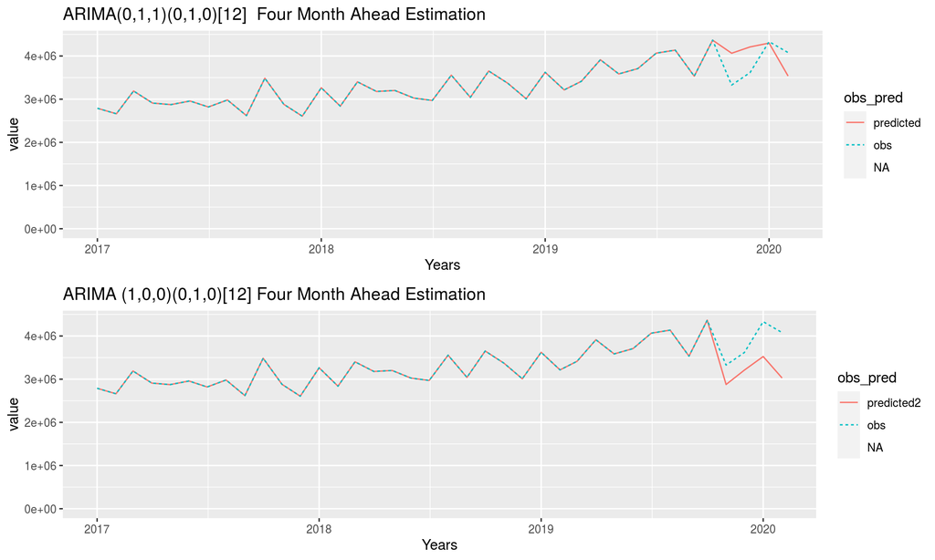

```r
grid.arrange(A_1mo, B_1mo, nrow = 2)
```

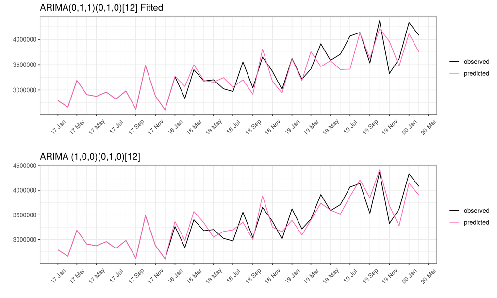

```r
grid.arrange(fitted1, fitted2, nrow = 2)
```

### 8. Additional Forecast View on the Data

First ARIMA model (0,1,1)(0,1,0)[12] is still more appropriate because of lower AIC.  
Moreover, second model changed its order since last analysis, even though number of observations stayed the same. Such change is not appropriate for the purpose of forecasting, since effective model need to be reliable.  
Additionally, residuals of the second model seem to be NOT randomly distributed, but correlated. Such residual behavior suggests that assumption on randomisation would not hold, and model would not be sufficient in this case.

```r
ts_f <- ts(dataset$TotalInv[13:46], frequency = 12, start = c(2017,
    1))
ts1_f <- window(ts_f)

summary(arima1_ <- auto.arima(ts1_f, D = 1, seasonal = TRUE))  #AIC=584.4
```

```
## Series: ts1_f
## ARIMA(0,1,1)(0,1,0)[12]
##
## Coefficients:
##           ma1
##       -0.7156
## s.e.   0.1429
##
## sigma^2 estimated as 5.984e+10:  log likelihood=-290.2
## AIC=584.4   AICc=585.07   BIC=586.49
##
## Training set error measures:
##                    ME     RMSE      MAE       MPE     MAPE
## Training set 26219.27 187611.7 109289.2 0.5487201 3.086263
##                   MASE        ACF1
## Training set 0.2623992 -0.06469472
```

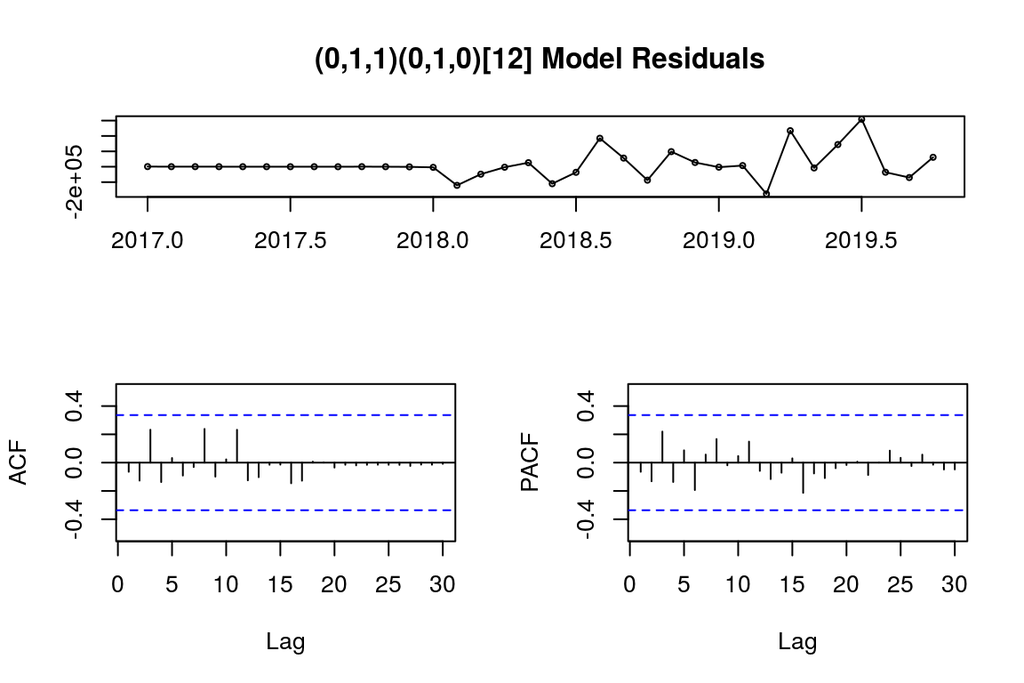

```r
fcast1 <- forecast(arima1_, h = 12)
tsdisplay(residuals(arima1_), lag.max = 30, main = "(0,1,1)(0,1,0)[12] Model Residuals")
```

```r
summary(arima2_ <- auto.arima(ts1_f, D = 1, seasonal = TRUE,
    xreg = as.numeric(ts(dataset$TotalUniqShipTos[13:46], frequency = 12,
        start = c(2017, 1)))))  #AIC=598.61
```

```
## Series: ts1_f
## Regression with ARIMA(0,0,0)(0,1,0)[12] errors
##
## Coefficients:
##           drift      xreg
##       19713.563  392.7196
## s.e.   4324.264   80.5847
##
## sigma^2 estimated as 3.217e+10:  log likelihood=-296.31
## AIC=598.61   AICc=599.95   BIC=601.89
##
## Training set error measures:
##                    ME     RMSE      MAE        MPE     MAPE
## Training set 180.7058 137566.7 95800.96 -0.1682475 2.789939
##                   MASE     ACF1
## Training set 0.2300144 0.317816
```

[figure not shown]

```r
fcast2 <- forecast(arima2_, h = 1, xreg = as.numeric(dataset$TotalUniqShipTos[13:46]))
tsdisplay(residuals(arima2_), lag.max = 30, main = "ARIMA(0,1,2)(0,1,0)[12] Model Residuals")
```

The desired outcome is to have the black line (observed values) to stay within the shaded area, which indicates a proper model forecasting technique.

Observed actual values show drop in sales as expected during pandemic. In terms of forecasting this period may look like outlier, since business was impacted by third factor and it is not typical direction sales trend took.

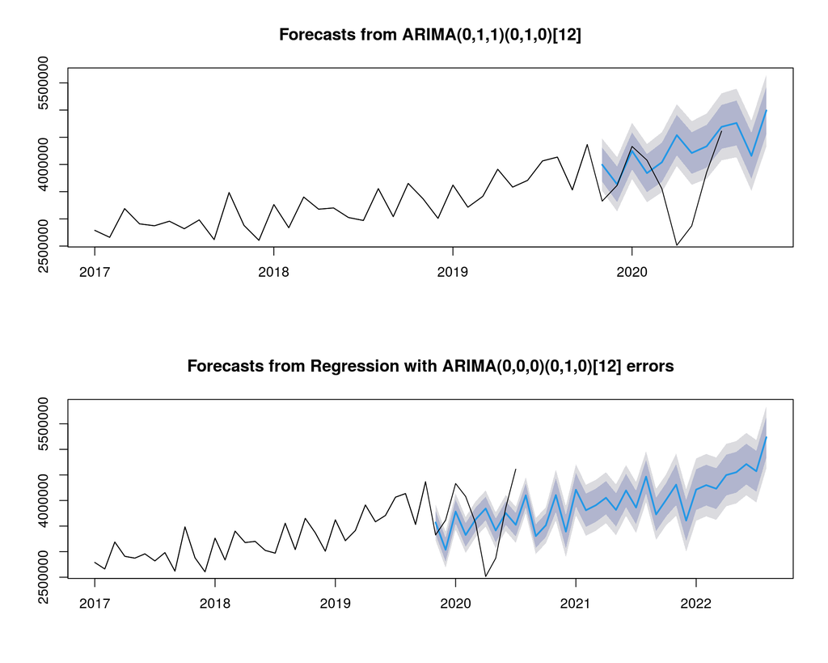

```r
par(mfrow = c(2, 1))
plot(fcast1)
lines((window(ts(dataset$TotalInv[13:55], frequency = 12, start = c(2017,
    1)), D = 1)))  # ARIMA(0,1,1)(0,1,0)[12]  order is  fitting ok in testing dataset

plot(fcast2)
lines((window(ts(dataset$TotalInv[13:55], frequency = 12, start = c(2017,
    1)), D = 1)))  # ARIMA(0,0,0)(0,1,0)[12] order is not fitting well in testing dataset
```

```r
par(mfrow = c(1, 1))
```

### 6. Using Arima Model (0,1,1)(0,1,0)[12] for finding values of future 12 months sales looks like following:

```r
(fcast_final <- forecast(arima1, h = 12))
```

```
##       Point Forecast   Lo 80   Hi 80   Lo 95   Hi 95
## Mar 4        4017981 3668884 4367078 3484083 4551879
## Apr 4        4516689 4160184 4873195 3971461 5061917
## May 4        4188466 3824703 4552229 3632138 4744794
## Jun 4        4311969 3941091 4682848 3744759 4879180
## Jul 4        4669346 4291485 5047206 4091458 5247233
## Aug 4        4740014 4355298 5124729 4151642 5328385
## Sep 4        4136704 3745254 4528155 3538033 4735376
## Oct 4        4970487 4572416 5368559 4361690 5579285
## Nov 4        3930404 3525820 4334988 3311646 4549162
## Dec 4        4219956 3808962 4630949 3591395 4848516
## Jan 5        4935950 4518646 5353255 4297738 5574163
## Feb 5        4683235 4259713 5106757 4035514 5330955
```

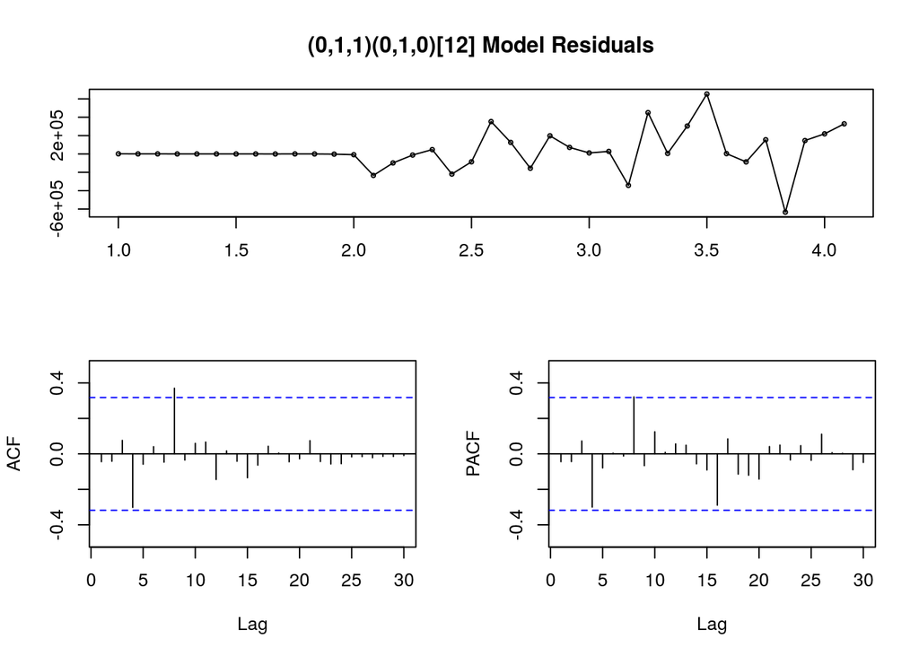

```r
tsdisplay(residuals(arima1), lag.max = 30, main = "(0,1,1)(0,1,0)[12] Model Residuals")
```

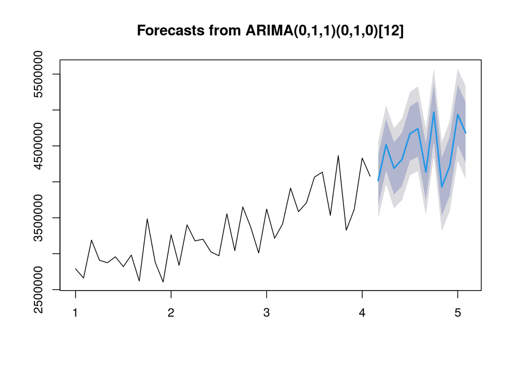

```r
plot(fcast_final)
lines((window(ts(dataset$TotalInv[13:50], frequency = 12, start = c(2017,
    1)), D = 1)))  # ARIMA(0,1,1)(0,1,0)[12]  order is  fitting ok in testing dataset
```

Actual Sales up to July look like following

```r
actuals <- dataset[51:55, c(3, 9)]




# actuals<-filter(dataset0, dataset0$Yr > 2019)
# actuals<-actuals[,c(1,2,3,9)] actuals<-
# actuals[order(actuals$Mo_No,decreasing = TRUE), ]
actuals
```

|  | Date | TotalInv |
| --- | --- | --- |
| 5 | 2020-03-01 | 3554428 |
| 4 | 2020-04-01 | 2514233 |
| 3 | 2020-05-01 | 2872116 |
| 2 | 2020-06-01 | 3857235 |
| 1 | 2020-07-01 | 4612485 |

```r
comp <- cbind(Date = as.Date(actuals$Date, origin = "1970-01-01"),
    predicted = fcast_final$mean[1:5], actuals = actuals$TotalInv,
    error_per = (fcast_final$mean[1:5] - actuals$TotalInv)/actuals$TotalInv *
        100)
comp
```

```
##       Date predicted actuals error_per
## [1,] 18322   4017981 3554428 13.041570
## [2,] 18353   4516689 2514233 79.644802
## [3,] 18383   4188466 2872116 45.832082
## [4,] 18414   4311969 3857235 11.789143
## [5,] 18444   4669346 4612485  1.232748
```

```r
library(lubridate)
comp <- data.frame(comp)
colnames(comp) <- c("Date", "Predicted", "Actuals", "Error in %")
comp$Date = as.Date(comp$Date, origin = "1970-01-01")
comp$Predicted <- as.numeric(comp$Predicted)
comp$Actuals <- as.numeric(comp$Actuals)
des(comp)
```

```
##
##  No. of observations =  5
##   Variable      Class           Description
## 1 Date          Date
## 2 Predicted     numeric
## 3 Actuals       numeric
## 4 Error in %    numeric
```

```r
comp
```

| Date | Predicted | Actuals | Error in % |
| --- | --- | --- | --- |
| 2020-03-01 | 4017981 | 3554428 | 13.041570 |
| 2020-04-01 | 4516689 | 2514233 | 79.644802 |
| 2020-05-01 | 4188466 | 2872116 | 45.832082 |
| 2020-06-01 | 4311969 | 3857235 | 11.789143 |
| 2020-07-01 | 4669346 | 4612485 | 1.232748 |

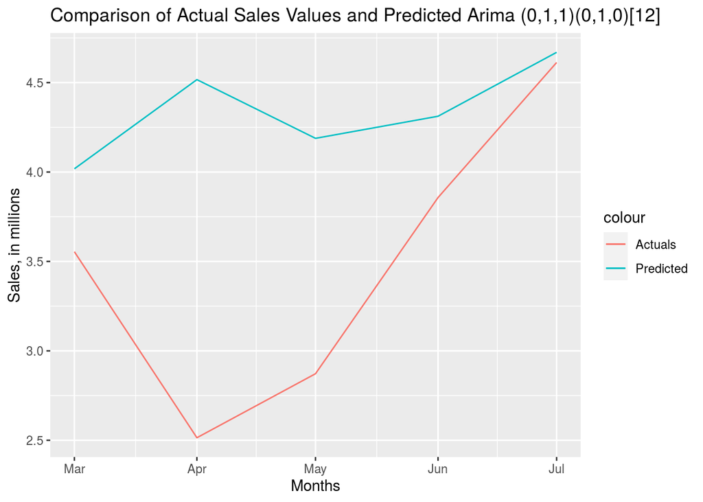

```r
# comp<-fortify(comp)
ggplot(comp, aes(x = Date, group = 1)) + geom_line(aes(y = Actuals/1e+06,
    col = "Actuals")) + geom_line(aes(y = Predicted/1e+06, col = "Predicted")) +
    xlab("Months") + ylab("Sales, in millions") + ggtitle("Comparison of Actual Sales Values and Predicted Arima (0,1,1)(0,1,0)[12]")
```